## Setup

### Load packages

```r
library(ggplot2)
library(dplyr)
library(statsr)
library(BAS)
library(tidyverse)
```

### Load data

Make sure your data and R Markdown files are in the same directory. When loaded your data file will be called `movies`. Delete this note when before you submit your work.

```r
load("movies.Rdata")
```

## Part 1: Data

The observations in the sample are collected from movie infomation from [Rotten Tomatoes](https://www.rottentomatoes.com/) and [IMDB](https://www.imdb.com/) based on a random sample of movies. Random sampling ensures that the sample is representative of the population, which means that any conclusions drawn from the sample is generalizable to the population.

## Part 2: Data manipulation

```r
movies <- movies %>% mutate(feature_film = ifelse(title_type == 'Feature Film', 'yes', 'no'),
                            drama = ifelse(genre == 'Drama', 'yes', 'no'),
                            mpaa_rating_R = ifelse(mpaa_rating == 'R', 'yes', 'no'),
                            oscar_season = ifelse(thtr_rel_month >= 10, 'yes', 'no'),
                            summer_season = ifelse(between(thtr_rel_month, 5, 8), 'yes', 'no'))
```

## Part 3: Exploratory data analysis

```r
movies %>%
  filter(feature_film == 'yes') %>%
  summarise(mean_feature = mean(audience_score), sd_feature = sd(audience_score), n_feature = n())
```

```
## # A tibble: 1 x 3
##   mean_feature sd_feature n_feature
##          <dbl>      <dbl>     <int>
## 1         60.5       19.8       591
```

```r
movies %>%
  filter(feature_film == 'no') %>%
  summarise(mean_no_feature = mean(audience_score), sd_no_feature = sd(audience_score), n_no_feature = n())
```

```
## # A tibble: 1 x 3
##   mean_no_feature sd_no_feature n_no_feature
##             <dbl>         <dbl>        <int>
## 1            81.0          13.6           60
```

Statistical summaries for feature films and non-feature films are shown as above. Non-feature films seem to have a much higher mean `audience_score` than feature films.

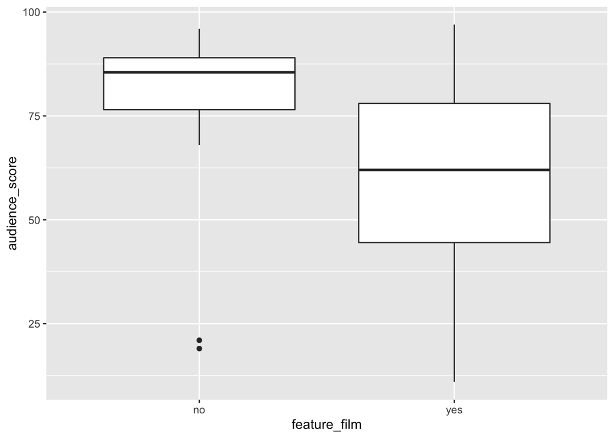

```r
ggplot(movies, aes(x = feature_film, y = audience_score)) +
  geom_boxplot()
```

Paired box plots for feature films and non-feature films are plotted as above. In addition to difference in mean `audience_score`, this plot also shows a more concentrated distribution for non-feature films. There are two outliers in non-feature films, while no outlier is found for feature films.

```r
movies %>%
  filter(drama == 'yes') %>%
  summarise(mean_drama = mean(audience_score), sd_drama = sd(audience_score), n_drama = n())
```

```
## # A tibble: 1 x 3
##   mean_drama sd_drama n_drama
##        <dbl>    <dbl>   <int>
## 1       65.3     18.5     305
```

```r
movies %>%
  filter(drama == 'no') %>%
  summarise(mean_no_drama = mean(audience_score), sd_no_drama = sd(audience_score), n_no_drama = n())
```

```
## # A tibble: 1 x 3
##   mean_no_drama sd_no_drama n_no_drama
##           <dbl>       <dbl>      <int>
## 1          59.7        21.3        346
```

Statistical summaries for dramas and non-dramas are shown as above. While the difference in mean `audience_score` between the two types is not obvious, dramas seem to have a higher average audience rating.

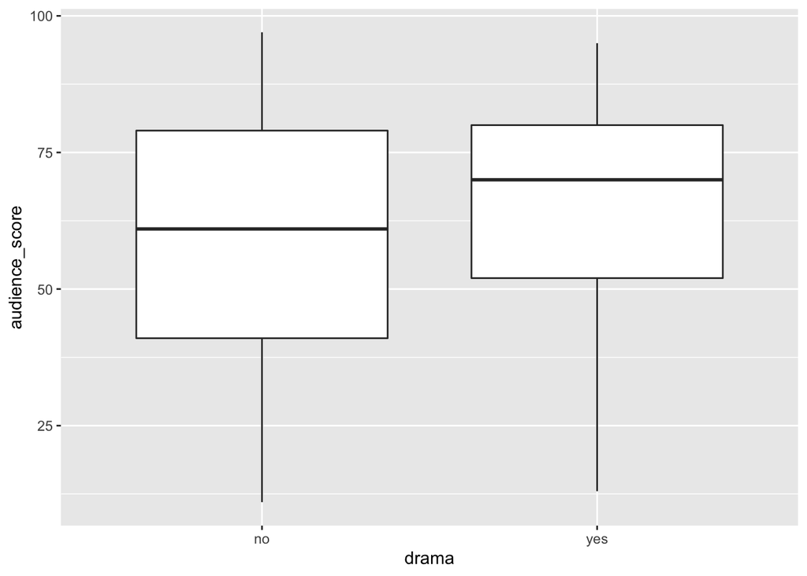

```r
ggplot(movies, aes(x = drama, y = audience_score)) +
  geom_boxplot()
```

Paired box plots for dramas and non-dramas are plotted as above. Non-dramas seem to have a higher inter-quartile range.

```r
movies %>%
  filter(mpaa_rating_R == 'yes') %>%
  summarise(mean_R = mean(audience_score), sd_R = sd(audience_score), n_R = n())
```

```
## # A tibble: 1 x 3
##   mean_R  sd_R   n_R
##    <dbl> <dbl> <int>
## 1   62.0  20.2   329
```

```r
movies %>%
  filter(mpaa_rating_R == 'no') %>%
  summarise(mean_no_R = mean(audience_score), sd_no_R = sd(audience_score), n_no_R = n())
```

```
## # A tibble: 1 x 3
##   mean_no_R sd_no_R n_no_R
##       <dbl>   <dbl>  <int>
## 1      62.7    20.3    322
```

Statistical summaries for R-rated films and non-R-rated films are shown as above. The distributions for both types of films don’t differ too much.

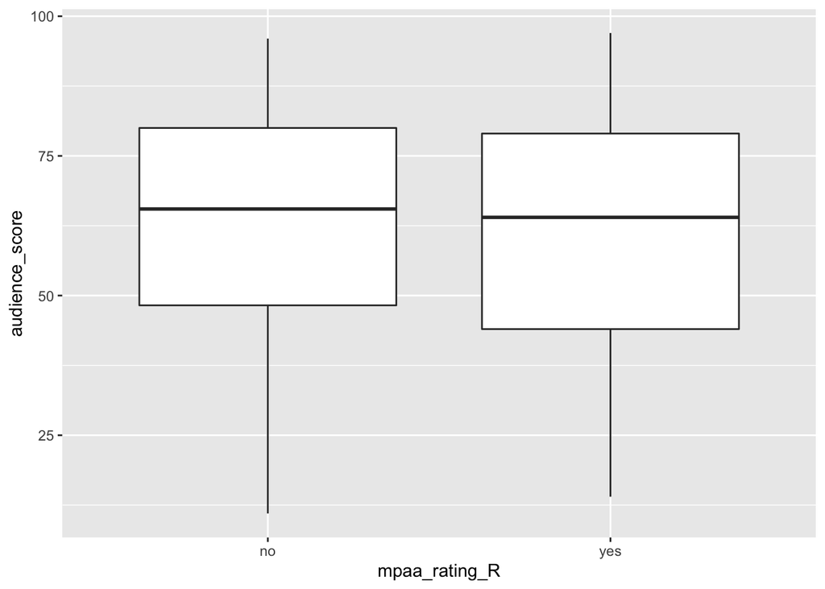

```r
ggplot(movies, aes(x = mpaa_rating_R, y = audience_score)) +
  geom_boxplot()
```

Paired box plots for R-rated films and non-R-rated films are plotted as above.

```r
movies %>%
  filter(oscar_season == 'yes') %>%
  summarise(mean_oscar = mean(audience_score), sd_oscar = sd(audience_score), n_oscar = n())
```

```
## # A tibble: 1 x 3
##   mean_oscar sd_oscar n_oscar
##        <dbl>    <dbl>   <int>
## 1       63.7     20.5     191
```

```r
movies %>%
  filter(oscar_season == 'no') %>%
  summarise(mean_no_oscar = mean(audience_score), sd_no_oscar = sd(audience_score), n_no_oscar = n())
```

```
## # A tibble: 1 x 3
##   mean_no_oscar sd_no_oscar n_no_oscar
##           <dbl>       <dbl>      <int>
## 1          61.8        20.1        460
```

Statistical summaries for films released in Oscar season and films not released in Oscar season are shown as above. Again, the distributions of the two types of films do not seem to differ significantly.

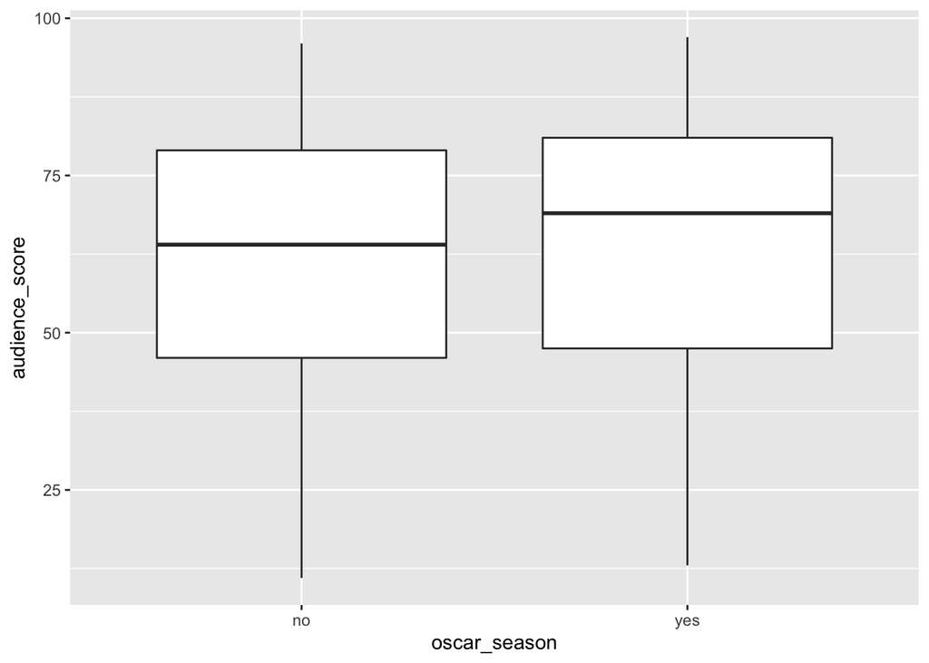

```r
ggplot(movies, aes(x = oscar_season, y = audience_score)) +
  geom_boxplot()
```

Paired box plots for films released in Oscar season and films not released in Oscar season are plotted as above.

```r
movies %>%
  filter(summer_season == 'yes') %>%
  summarise(mean_summer = mean(audience_score), sd_summer = sd(audience_score), n_summer = n())
```

```
## # A tibble: 1 x 3
##   mean_summer sd_summer n_summer
##         <dbl>     <dbl>    <int>
## 1        61.8      19.9      208
```

```r
movies %>%
  filter(summer_season == 'no') %>%
  summarise(mean_no_summer = mean(audience_score), sd_no_summer = sd(audience_score), n_no_summer = n())
```

```
## # A tibble: 1 x 3
##   mean_no_summer sd_no_summer n_no_summer
##            <dbl>        <dbl>       <int>
## 1           62.6         20.4         443
```

Statistical summaries for films released in summer and films not released in the summer are shown as above. Whether or not a film is released in summer does not seem to influence the `audience_score` for the film too much.

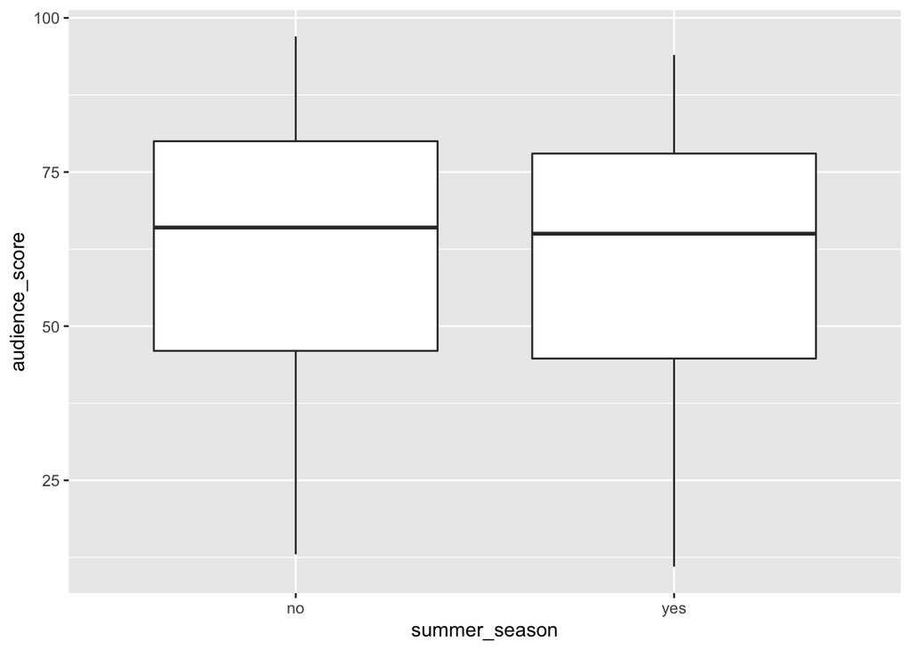

```r
ggplot(movies, aes(x = summer_season, y = audience_score)) +
  geom_boxplot()
```

Paired box plots for films released in summer and films not released in the summer are plotted as above. * * *

## Part 4: Modeling

First, we need to convert categorical labels to numerical values of 0’s and 1’s, with 0 representing “no” and 1 representing “yes”.

```r
# variable numericalization
movies <- movies %>% mutate(feature_film = ifelse(title_type == 'Feature Film', 1, 0),
                            drama = ifelse(genre == 'Drama', 1, 0),
                            mpaa_rating_R = ifelse(mpaa_rating == 'R', 1, 0),
                            oscar_season = ifelse(thtr_rel_month >= 10, 1, 0),
                            summer_season = ifelse(5 <= thtr_rel_month && thtr_rel_month <= 8, 1, 0),
                            best_pic_nom = ifelse(best_pic_nom == 'yes', 1, 0),
                            best_pic_win = ifelse(best_pic_win == 'yes', 1, 0),
                            best_actor_win = ifelse(best_actor_win == 'yes', 1, 0),
                            best_actress_win = ifelse(best_actress_win == 'yes', 1, 0),
                            best_dir_win = ifelse(best_dir_win == 'yes', 1, 0),
                            top200_box = ifelse(top200_box == 'yes', 1, 0))
```

### Model Selection

We are going to use Bayesian model averaging in order to account for the inherent uncertainty among the diffrent models. This way, we will average multiple models to ontain posteriors of coefficients and predictions for new data. Because there are in total $2^{16} = 65536$ models to explore, we should choose Markov Chain Monte Carlo to explore the model space.

```r
set.seed(0)
m_movies_score <- bas.lm(audience_score ~ feature_film+drama+runtime+mpaa_rating_R+thtr_rel_year+
                      oscar_season+summer_season+imdb_rating+imdb_num_votes+critics_score+
                      best_pic_nom+best_pic_win+best_actor_win+best_actress_win+best_dir_win+
                      top200_box, data = na.omit(movies),
                   prior = "ZS-null",
                   modelprior = uniform(),
                   method = "MCMC")
```

The following is a summary of the top few models.

```r
round(summary(m_movies_score), 3)
```

```
##                  P(B != 0 | Y) model 1 model 2 model 3 model 4 model 5
## Intercept                1.000   1.000   1.000   1.000   1.000   1.000
## feature_film             0.061   0.000   0.000   0.000   0.000   0.000
## drama                    0.048   0.000   0.000   0.000   0.000   0.000
## runtime                  0.512   0.000   1.000   1.000   0.000   1.000
## mpaa_rating_R            0.169   0.000   0.000   1.000   0.000   0.000
## thtr_rel_year            0.086   0.000   0.000   0.000   0.000   0.000
## oscar_season             0.070   0.000   0.000   0.000   0.000   0.000
## summer_season            0.000   0.000   0.000   0.000   0.000   0.000
## imdb_rating              1.000   1.000   1.000   1.000   1.000   1.000
## imdb_num_votes           0.068   0.000   0.000   0.000   0.000   0.000
## critics_score            0.917   1.000   1.000   1.000   1.000   1.000
## best_pic_nom             0.138   0.000   0.000   0.000   0.000   1.000
## best_pic_win             0.043   0.000   0.000   0.000   0.000   0.000
## best_actor_win           0.118   0.000   0.000   0.000   0.000   0.000
## best_actress_win         0.150   0.000   0.000   0.000   1.000   0.000
## best_dir_win             0.070   0.000   0.000   0.000   0.000   0.000
## top200_box               0.051   0.000   0.000   0.000   0.000   0.000
## BF                          NA   0.993   1.000   0.204   0.207   0.186
## PostProbs                   NA   0.158   0.157   0.032   0.032   0.029
## R2                          NA   0.746   0.748   0.750   0.747   0.750
## dim                         NA   3.000   4.000   5.000   4.000   5.000
## logmarg                     NA 413.875 413.882 412.294 412.309 412.198
```

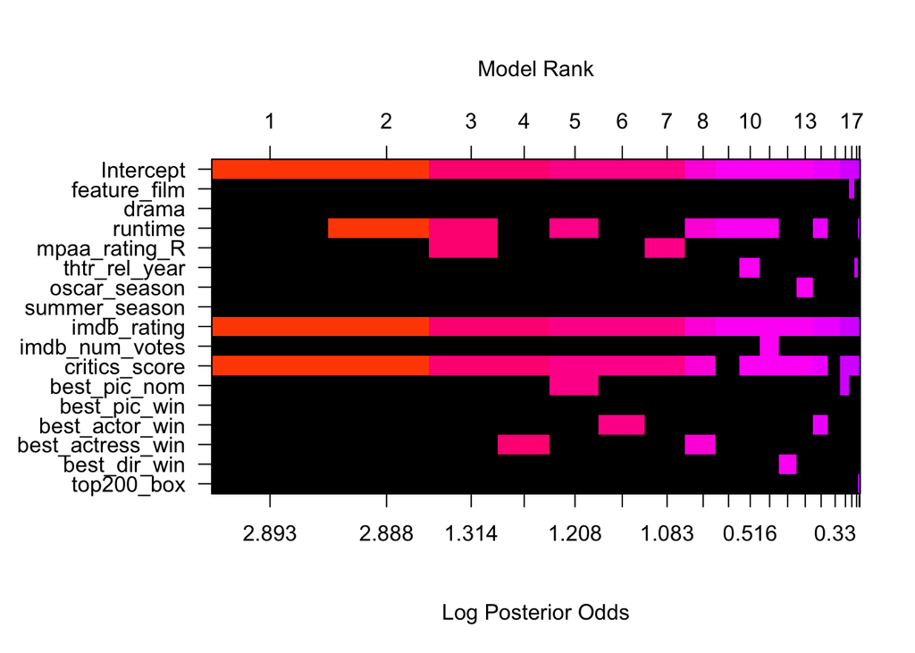

```r
image(m_movies_score, rotate = F)
```

It is very obvious that `critics_score` and `imdb_rating` are the top 2 most important variables for predicting a movie’s `audience_score`.

### Diagnostics

Now we are going to run some diagnostics on the linear model we just obtained.

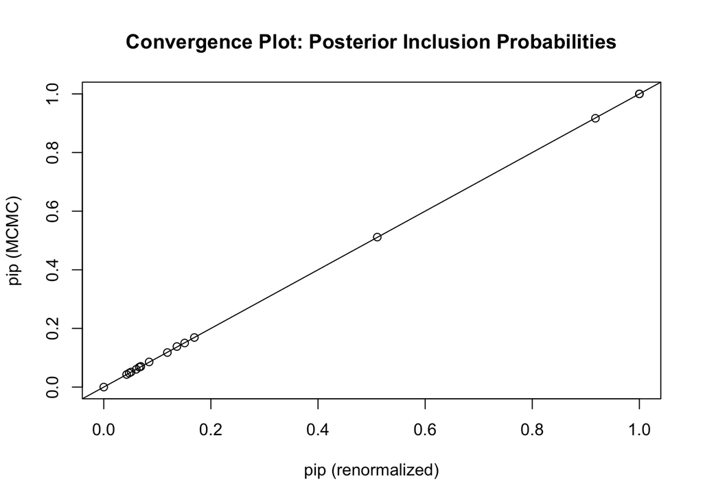

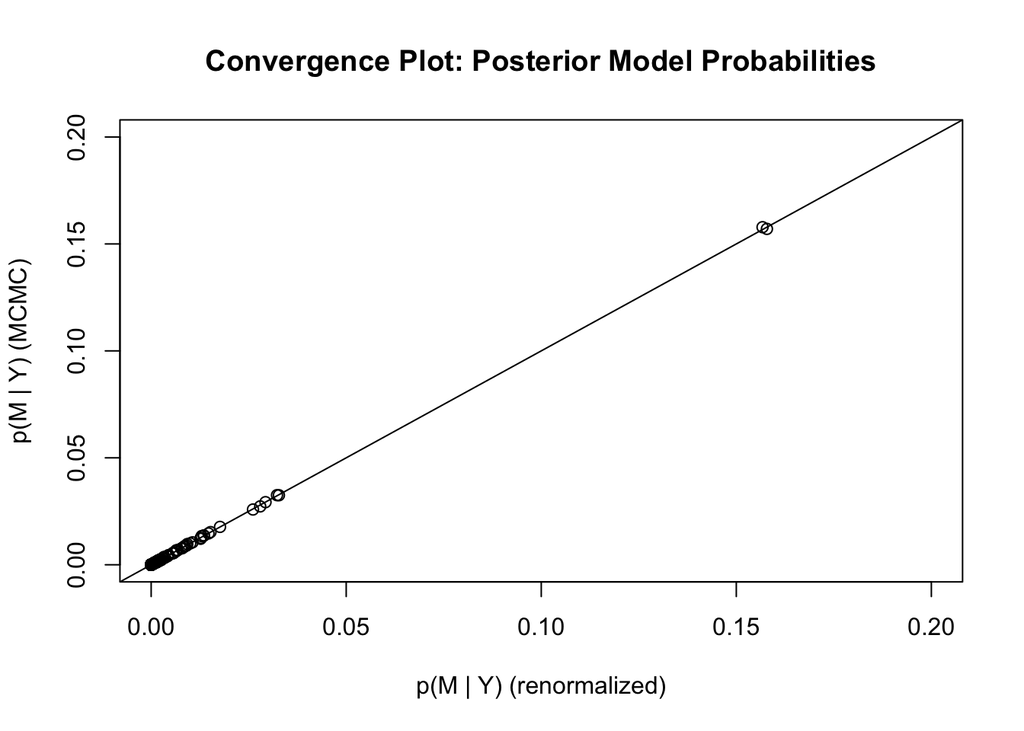

```r
diagnostics(m_movies_score)
```

By looking at this diagnostic plot, we can determine whether we have run the MCMC exploration long enough so that the posterior inclusion probability (pip) has converged. Each point in the plot represents a posterior inclusion probability for one variable. As we can see from the plot, the renormalized posterior inclusion probability (x-axis) and the posterior inclusion probability (y-axis) of each coefficient are in close agreement. Therefore, we can conclude that we have already run enough number of MCMC exploration iterations.

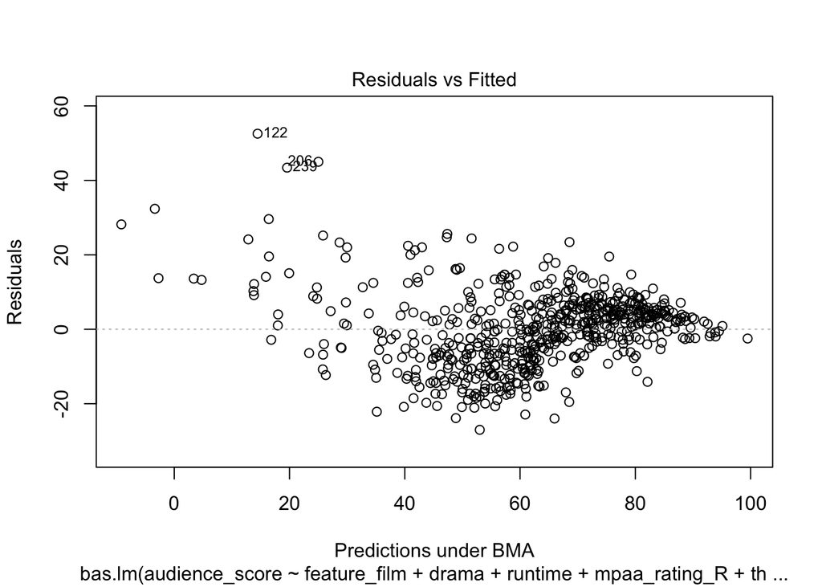

```r
plot(m_movies_score, which = 1, add.smooth = F)
```

As we can see from this residual plot, there are 3 outliers. Although the residuals are somewhat clustered in some parts of the graph, the distribution of residuals is still roughly random overall.

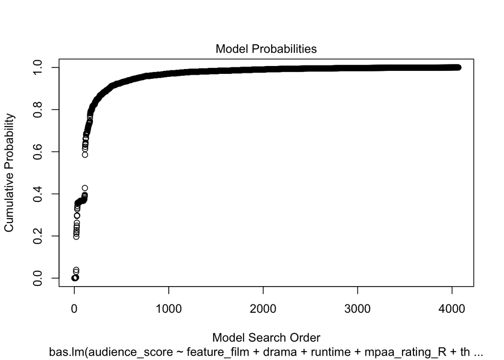

```r
plot(m_movies_score, which = 2, add.smooth = F)
```

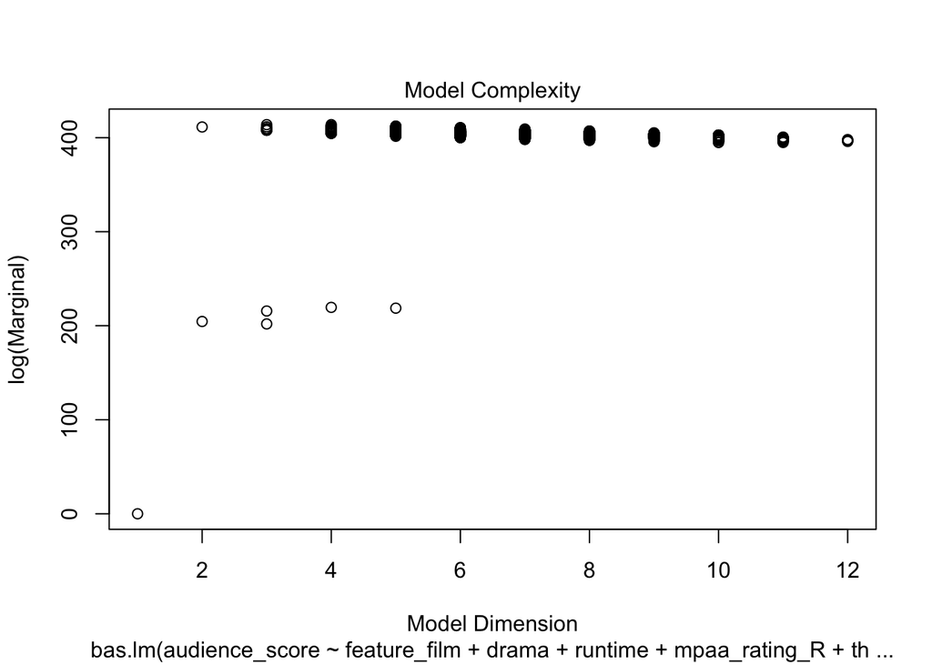

```r
plot(m_movies_score, which = 3)
```

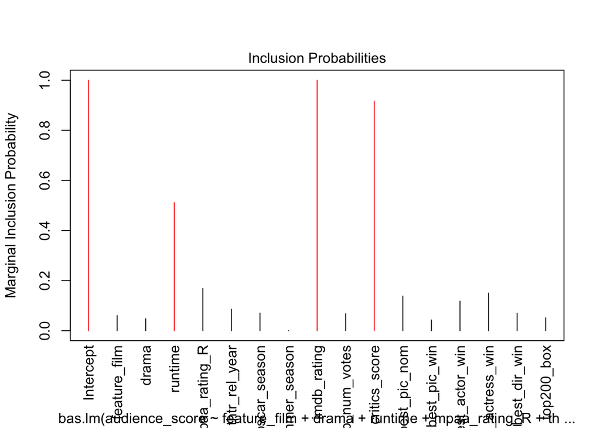

```r
plot(m_movies_score, which = 4)
```

As noted before, the `critics_score` and `imdb_rating` are the two mosting important variables for making the prediction. But the `runtime` of the movie plays a big role in prediction as well.

### Interpretation of Coefficients

```r
coefficients(m_movies_score)
```

```
##
##  Marginal Posterior Summaries of Coefficients:
##
##  Using  BMA
##
##  Based on the top  4067 models
##                   post mean   post SD     post p(B != 0)
## Intercept          6.221e+01   4.088e-01   1.000e+00
## feature_film      -9.362e-02   5.672e-01   6.058e-02
## drama              2.156e-02   2.151e-01   4.779e-02
## runtime           -3.031e-02   3.399e-02   5.115e-01
## mpaa_rating_R     -2.467e-01   6.427e-01   1.690e-01
## thtr_rel_year     -4.134e-03   1.767e-02   8.575e-02
## oscar_season      -6.893e-02   3.554e-01   7.044e-02
## summer_season      0.000e+00   0.000e+00   0.000e+00
## imdb_rating        1.488e+01   7.457e-01   1.000e+00
## imdb_num_votes     2.742e-07   1.509e-06   6.783e-02
## critics_score      6.931e-02   3.001e-02   9.169e-01
## best_pic_nom       5.390e-01   1.621e+00   1.383e-01
## best_pic_win      -8.021e-03   8.940e-01   4.282e-02
## best_actor_win    -2.150e-01   7.217e-01   1.178e-01
## best_actress_win  -3.370e-01   9.527e-01   1.503e-01
## best_dir_win      -1.216e-01   6.323e-01   6.976e-02
## top200_box         9.465e-02   7.402e-01   5.144e-02
```

On average, `drama`, `imdb_rating`, `imdb_num_votes`, `critics_score`, `best_pic_nom`, `best_pic_nom`, and `top200_box` are positively correlated with `audience_score`; `summer_session` does not have correlation with `audience_score`; the rest of the variables all have negative correlation with `audience_score`. * * *

## Part 5: Prediction

We are going to predict the `audience_score` of Captain America: Civil War.

```r
captain_america_3 <- data.frame(feature_film = 0, drama = 0, runtime = 147, mpaa_rating_R = 0, thtr_rel_year = 2016, oscar_season = 0, summer_season = 1, imdb_rating = 7.8, imdb_num_votes = 589113, critics_score = 91, best_pic_nom = 0, best_pic_win = 0, best_actor_win = 1, best_actress_win = 1, best_dir_win = 0, top200_box = 1)
```

```r
round(predict(m_movies_score, captain_america_3, estimator = "BMA")$fit, 0)
```

```
## [1] 83
```

The predicted `audience_score` for Captain America: Civil War is 83.

## Part 6: Conclusion

We have obtained a fairly good linear model for making predictions on the `audience_score` of a movie. A large dimension of a model is not necessarily an indicator of the goodness of the model. A linear model with a few powerful predictor variables sometimes can already do a good job in making predictions. The shortcoming of my current study is that I have not tried building a linear model with different prior probability distributions, which may make my analysis not wholistic enough.